# R ve fyzické geografii: ggplot2, přednastavené motivy (témata) a panely (facety)

Autor

Ondřej Ledvinka

Publikováno

27. října 2026

Upraveno

23. října 2026

## Prerekvizity

Jedná se o bonusový učební text, který zakládá na dotazech studentů týkajících výberu finálních motivů (*themes)* pro ggplot2 grafy. Rovnou také ukážeme, jak rychle získat tzv. facety (panely, podgrafy) grafů založené na kategorické proměnné. Text se opírá o několik zatím neznámých balíčků, z nichž některé ani nenajdeme na CRAN, ale pouze na vývojářské síti GitHub. Budeme tedy muset ukázat postup, jak instalovat balíčky z GitHub. Zaroveň se samozřejmě předpokládá, že pracujeme s nejnovějšími verzemi `R` a IDE RStudio. Samozřejmostí je rovněž kvalitní připojení k internetu, protože budeme instalovat nové balíčky.

## Instalace balíčků z GitHub a načtení balíčků do prostředí pro další práci

Jeden ze zajímavých balíčků přinášející vtipné motivy inspirované televizními seriály je balíček `ThemePark`. Ten ale nenalezneme na žádném zrcadle CRAN, nýbrž na GitHubu. Abychom mohli nainstalovat balíček z GitHubu, potřebujeme funkci `remotes::install_github()`. To znamená, že nejprve potřebujeme také balíček `remotes`, i když ho nebudeme načítat celý.

```r
# předpokládejme, že balíček remotes již nainstalovaný máme
# můžeme tedy využít funkci install_github()
# na GitHub stránkách balíčku ThemePark se dozvídáme, jakou cestu máme funkci zadat
remotes::install_github("MatthewBJane/ThemePark")

# nyní načteme balíčky pro další práci
# možná bude potřeba některé z nich instalovat z CRAN, tak zvolíme pkg_attach2()
xfun::pkg_attach2(
  "tidyverse",
  "units",
  "ggforce",
  "ggthemes", # asi nejznámější balíček dodávající další funkce 'theme_'
  "ThemePark" # balíček jsme právě nainstalovali
)
```

## Práce s dalšími funkcemi ‘theme_’

Předpokládejme, že naše dřívější grafy založené na datasetu `trees` budeme chtít ozvláštnit nějakým přednastaveným motivem. Už i v samotném balíčku `ggplot2` najdeme některé motivy, které se nastavují funkcemi, jejichž názvy začínají na `theme_`. Nejprve tedy opět upravíme vhodně náš dataset se stromy a pak budeme demonstrovat tyto funkce.

```r
# vezmeme opět dataset se stromy, který přichází s R rovnou, a není tedy potřeba nic dalšího instalovat
trees <-
  trees |>
  as_tibble() |>
  janitor::clean_names() |>
  mutate(
    girth = set_units(girth, "in") |>
      set_units("cm"),
    height = set_units(height, "ft") |>
      set_units("m"),
    volume = set_units(volume, "ft3") |>
      set_units("m3")
  )

# nakresleme nějaký základ
# uložme si ho zámerně do objektu p1
p1 <-
  ggplot(
  trees,
  aes(
    x = girth,
    y = height
  )
) +
  geom_point(
    aes(size = volume),
    col = "darkolivegreen"
  ) +
  geom_smooth(
    method = "lm",
    se = F,
    linetype = 4,
    linewidth = 1,
    col = "red"
  ) +
  labs(
    title = "Závilost výšky střemchy pozdní na obvodu kmene",
    subtitle = "autor: O. Ledvinka",
    caption = "zdroj dat: R balíček datasets",
    x = "obvod kmene",
    y = "výška",
    size = "objem"
  )
```

Nyní máme základ grafu přiřazený k objektu `p1`. Využijme tento objekt a operátorem `+` na něj aplikume různé `theme_` funkce (z různých balíčků).

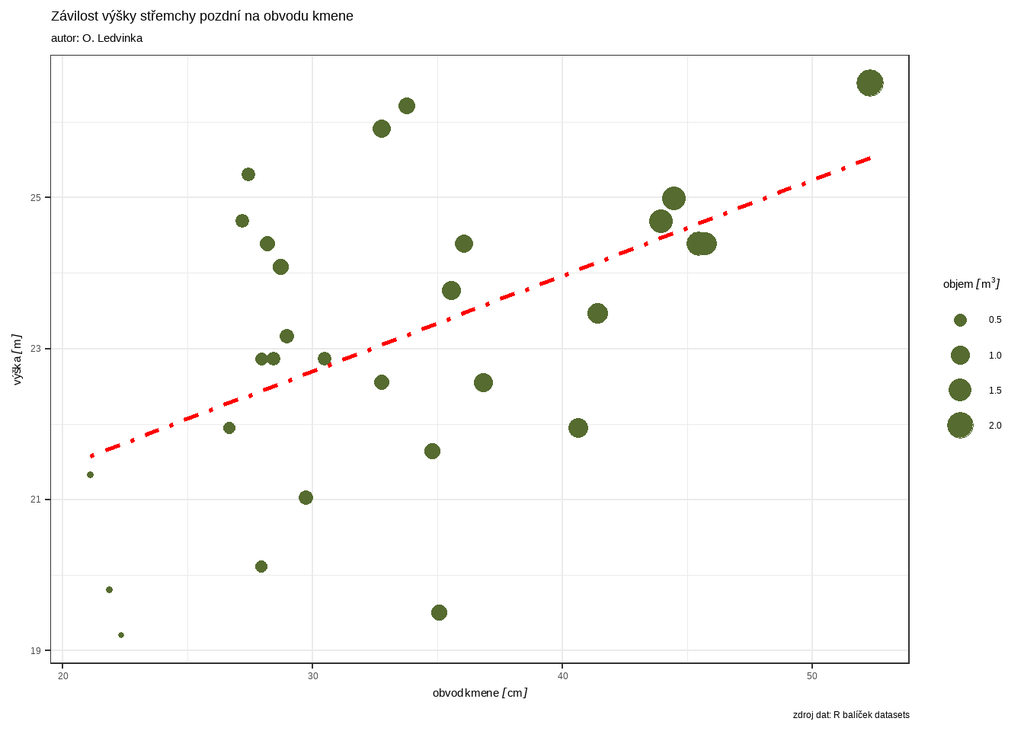

```r
# nejprve předveďme některé motivy pocházející přímo z balíčku ggplot2
p1 +
  theme_bw() # nastaví černobílý motiv
```

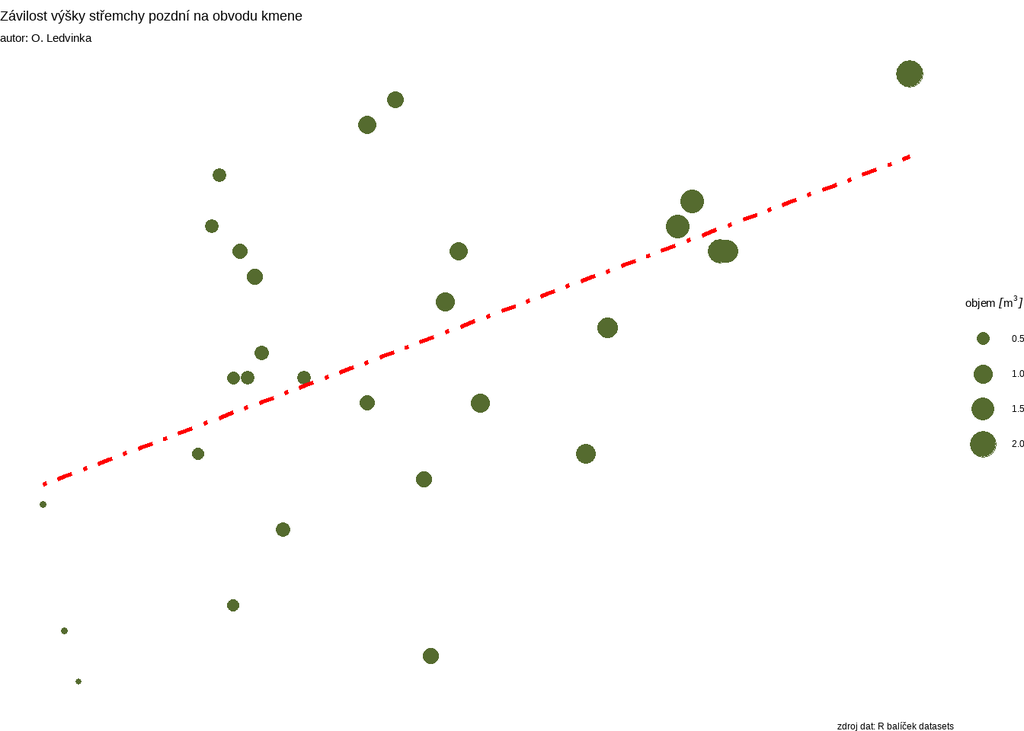

```r
p1 +
  theme_void() # odebere nepodstatné prvky tak, aby základ grafu mohl být vložen např. lokalizovaně do mapy
```

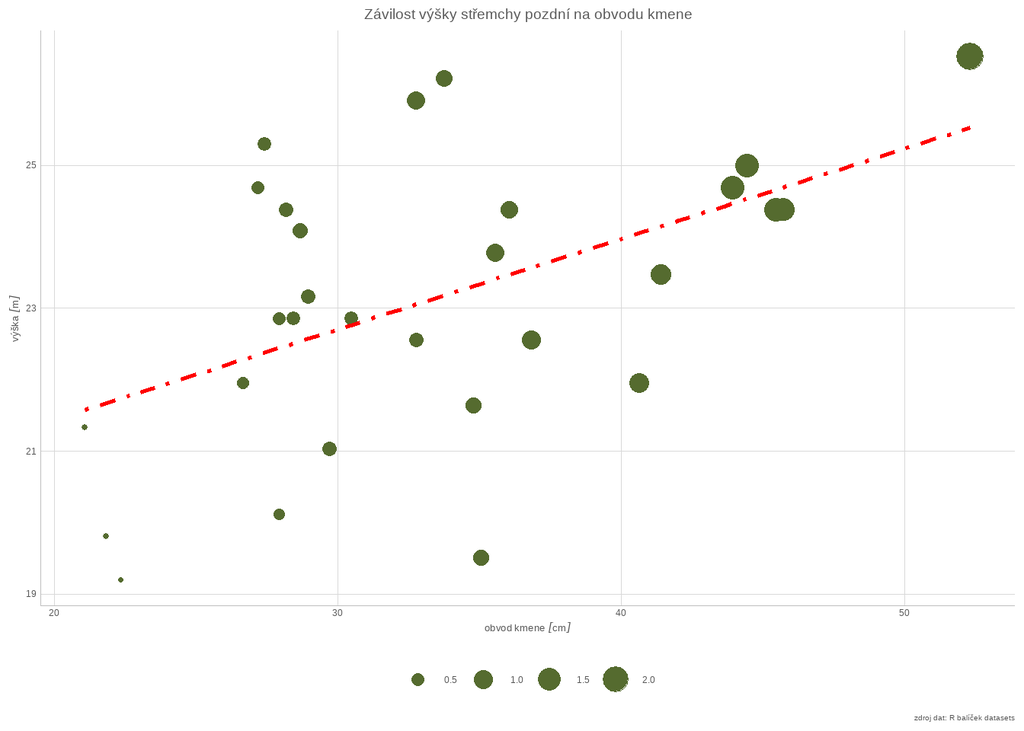

```r
# nyní funkce z balíčku ggthemes
p1 +
  theme_excel_new() # napodobí grafy s nových verzí MS Excel
```

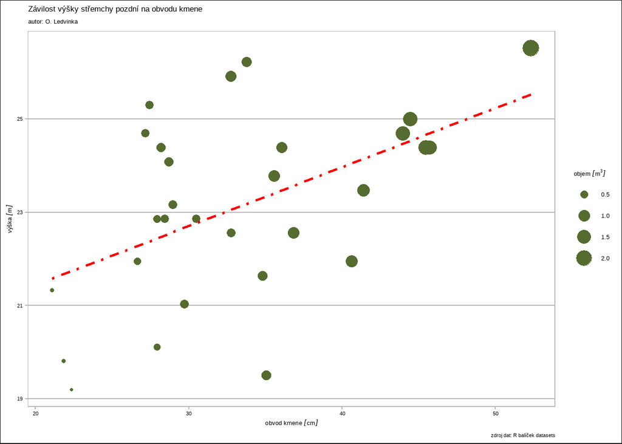

```r
p1 +
  theme_calc() # napodobí grafy z Libre Office Calc
```

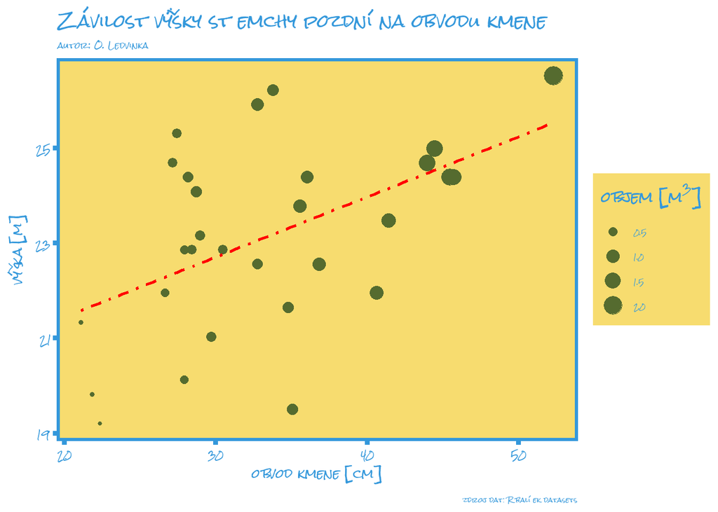

```r
# v neposlední řadě ukažme motivy z balíčku ThemePark
p1 +
  theme_simpsons() # navozuje pocit, jako bychom se dívali na písmo ze seriálu Simpsonovi
```

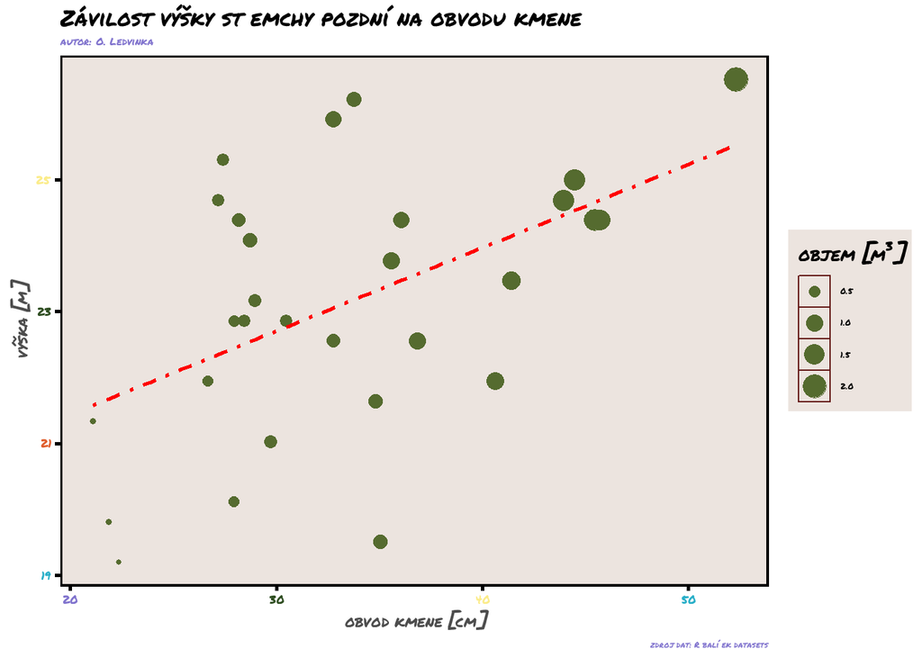

```r
p1 +
  theme_friends() # navozuje pocit, jako bychom se dívali na písmo ze seriálu Přátelé
```

```r
# je ale vidět, že některé motivy mají problém s českou diakritikou, tak volme obezřetně
```

Existují další balíčky přinášející motivy pro grafy tvořené logikou ggplot2. AI např. odkazuje na balíček `hrbrthemes`. Abychom mohli využít tzv. Markdown při popisování grafů (např. s využitím matematické notace), je také doporučován balíček `ggtext`, který dodává další pomocné funkce, jejichž název začíná na `element_`. Tyto funkce se vkládají do funkcí `theme_` k doladění popisků atp.[^1]

## Facety (neboli panely, podgrafy)

Velice efektivní při kreslení grafů ve smyslu ggplot2 jsou tzv. facety. V balíčku `ggplot2` se nacházejí dvě základní funkce, pomocí nichž lze graf rozdělit podle nějaké proměnné (nejčastěji kategorické). Těmito funkcemi jsou `facet_wrap()` a `facet_grid()`. Ukažne si tedy, jak např. pracovat s funkcí `facet_wrap()`. Nejprve ale budeme muset získat nějakou kategorickou proměnnou (s třídou *factor*, která se pod sloupci *tibble* objektu ukazuje jako `<fct>`).

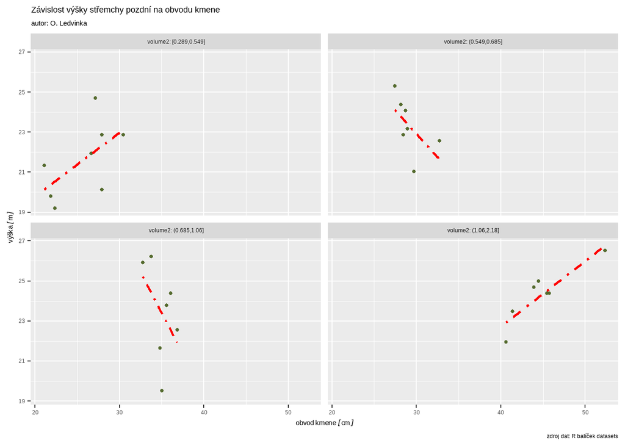

```r
# řekněme, že kategorickou proměnnou chceme získat z objemu tak, že tuto numerickou veličinu převedeme na faktor
# už jsme se nepatrně dotkli funkce cut(), která numerické proměnné konvertuje na intervaly podle nějakého pravidla
# my si ale pomůžeme vestavěnými funkcemi balíčku ggplot2
trees <-
  trees |>
  mutate(
    volume2 = drop_units(volume) |> # musíme se zbavit jednotek, jinak to nebude fungovat
      cut_number(n = 4) # tuto funkci z ggplot2 využijeme, když máme podezření na šikmé rozdělení proměnné a chceme intervaly s podobným počtem členů
  )

# nyní již můžeme ukázat sílu facet
# odhlédněme nyní od objektu p1, kde je objem využit pro velikost bodu
ggplot(
  trees,
  aes(
    x = girth,
    y = height
  )
) +
  geom_point(
    col = "darkolivegreen",
    size = 1
  ) +
  geom_smooth(
    method = "lm",
    se = F,
    col = "red",
    linetype = 4,
    linewidth = 1
  ) +
  facet_wrap(~volume2, # funkce akceptuje tildu a název proměnné, podle které chceme graf dělit; můžeme si dokonce diktovat, kolik má být řádků a kolik sloupců
             labeller = label_both # zde jsme použili pojmenovanou funkci label_both(), aby se ukázal název třetí proměnné
             ) +
  labs(
    title = "Závislost výšky střemchy pozdní na obvodu kmene",
    subtitle = "autor: O. Ledvinka",
    caption = "zdroj dat: R balíček datasets",
    x = "obvod kmene",
    y = "výška"
  )
```

```r
# zeptejte se AI, jak by bylo možné panely pojmenovat vlastními popisky
```

Vidíme, že se dokonce sestavily separátní lineární modely pro konstrukci regresní přímky.

Dodejme, že funkce `facet_grid()` akceptuje dvě proměnné – pomyslně řádky a sloupce. Jde o velice efektivní členění grafu, díky kterému můžeme zkoumat vliv třetí a čtvrté proměnné, a tak vlastně i tzv. interakce.

## Poznámky pod čarou

[^1]: Viněta k balíčku `ggtext` na https://wilkelab.org/ggtext/articles/plotting_text.html, prozrazuje mnohem více.